# Assignment

Praveen S

16 September 2017

## Machine Learning Assignment

### Introduction

This document describes how to build a predictive model for the weight lifting exercises data set. The main objective is to predict the kind of weight lifting performed for a given set of data. It is observed that we can fit a Random Forest Model which can predict on test data with good accuracy.

### Data input and cleansing

We will check the data for training and validation.In the input pml training data there are a number of variables that are set to factor but actually which are numeric.

```r
pm1.data <- read.csv("pml-training.csv", na.strings = c("NA",""))
str(pm1.data)
```

```
## 'data.frame':    19622 obs. of  160 variables:
##  $ X                       : int  1 2 3 4 5 6 7 8 9 10 ...
##  $ user_name               : Factor w/ 6 levels "adelmo","carlitos",..: 2 2 2 2 2 2 2 2 2 2 ...
##  $ raw_timestamp_part_1    : int  1323084231 1323084231 1323084231 1323084232 1323084232 1323084232 1323084232 1323084232 1323084232 1323084232 ...
##  $ raw_timestamp_part_2    : int  788290 808298 820366 120339 196328 304277 368296 440390 484323 484434 ...
##  $ cvtd_timestamp          : Factor w/ 20 levels "02-12-2011 13:32",..: 9 9 9 9 9 9 9 9 9 9 ...
##  $ new_window              : Factor w/ 2 levels "no","yes": 1 1 1 1 1 1 1 1 1 1 ...
##  $ num_window              : int  11 11 11 12 12 12 12 12 12 12 ...
##  $ roll_belt               : num  1.41 1.41 1.42 1.48 1.48 1.45 1.42 1.42 1.43 1.45 ...
##  $ pitch_belt              : num  8.07 8.07 8.07 8.05 8.07 8.06 8.09 8.13 8.16 8.17 ...
##  $ yaw_belt                : num  -94.4 -94.4 -94.4 -94.4 -94.4 -94.4 -94.4 -94.4 -94.4 -94.4 ...
##  $ total_accel_belt        : int  3 3 3 3 3 3 3 3 3 3 ...
##  $ kurtosis_roll_belt      : Factor w/ 396 levels "-0.01685","-0.021024",..: NA NA NA NA NA NA NA NA NA NA ...
##  $ kurtosis_picth_belt     : Factor w/ 316 levels "-0.021887","-0.060755",..: NA NA NA NA NA NA NA NA NA NA ...
##  $ kurtosis_yaw_belt       : Factor w/ 1 level "#DIV/0!": NA NA NA NA NA NA NA NA NA NA ...
```

[output cut: 86 more lines]

#### Inspecting levels of factor variables to find those with only useless levels

```r
for (colName in colnames(pm1.data[,sapply(pm1.data, class)=="factor"])){
  print(colName)
  print(levels(pm1.data[[colName]]))
}
```

```
## [1] "user_name"
## [1] "adelmo"   "carlitos" "charles"  "eurico"   "jeremy"   "pedro"
## [1] "cvtd_timestamp"
##  [1] "02-12-2011 13:32" "02-12-2011 13:33" "02-12-2011 13:34"
##  [4] "02-12-2011 13:35" "02-12-2011 14:56" "02-12-2011 14:57"
##  [7] "02-12-2011 14:58" "02-12-2011 14:59" "05-12-2011 11:23"
## [10] "05-12-2011 11:24" "05-12-2011 11:25" "05-12-2011 14:22"
## [13] "05-12-2011 14:23" "05-12-2011 14:24" "28-11-2011 14:13"
## [16] "28-11-2011 14:14" "28-11-2011 14:15" "30-11-2011 17:10"
## [19] "30-11-2011 17:11" "30-11-2011 17:12"
## [1] "new_window"
## [1] "no"  "yes"
## [1] "kurtosis_roll_belt"
##   [1] "-0.01685"  "-0.021024" "-0.025513" "-0.033935" "-0.034743"
##   [6] "-0.06016"  "-0.060755" "-0.080411" "-0.100466" "-0.15095"
```

[output cut: 1155 more lines]

#### Removing variables which are of no use from data set.

```r
variables <- c("X", "user_name", "raw_timestamp_part_1", "raw_timestamp_part_2",
  "kurtosis_yaw_belt", "skewness_yaw_belt", "amplitude_yaw_belt", "cvtd_timestamp",
  "kurtosis_yaw_dumbbell", "skewness_yaw_dumbbell", "amplitude_yaw_dumbbell",
  "kurtosis_yaw_forearm", "skewness_yaw_forearm", "amplitude_yaw_forearm")
pm1.data <- pm1.data[,-which(names(pm1.data) %in% variables)]
```

#### Convert factor variables which are numeric to numeric values.

```r
variables <- c("kurtosis_roll_belt", "kurtosis_picth_belt", "skewness_roll_belt",
  "skewness_roll_belt.1", "max_yaw_belt", "min_yaw_belt",
  "kurtosis_roll_arm","kurtosis_picth_arm", "kurtosis_yaw_arm",
  "skewness_roll_arm","skewness_pitch_arm", "skewness_yaw_arm",
  "kurtosis_roll_dumbbell", "kurtosis_picth_dumbbell","skewness_roll_dumbbell",
  "skewness_pitch_dumbbell","max_yaw_dumbbell", "min_yaw_dumbbell",
  "kurtosis_roll_forearm","kurtosis_picth_forearm", "skewness_roll_forearm",
  "skewness_pitch_forearm", "max_yaw_forearm", "min_yaw_forearm")

for (variable in variables) {

pm1.data[[variable]] <- as.numeric(as.character(pm1.data[[variable]]))
  }
```

[output not shown]

#### Many variables have NA values and we will build a model using variables that does not have any NA values.

```r
pm1.data.naCounts <- colSums(sapply(pm1.data,is.na))
pm1.data.full <- pm1.data[,pm1.data.naCounts == 0]
```

### Training the model

```r
library(caret)
set.seed(12344)
inTrain <- createDataPartition(pm1.data.full$classe,p=0.6,list = FALSE)

pm1.data.train <- pm1.data.full[inTrain, ]
pm1.data.test <- pm1.data.full[-inTrain, ]
```

```r
library(caret)
modelFit <- train(classe~ ., data = pm1.data.train, method="rf",importance=TRUE)
```

### Verify the model

#### Testing the model with the test data

```r
predictionResults <- confusionMatrix(pm1.data.test$classe, predict(modelFit, pm1.data.test))
predictionResults$table
```

```
##           Reference
## Prediction    A    B    C    D    E
##          A 2230    1    0    0    1
##          B    2 1515    1    0    0
##          C    0    3 1365    0    0
##          D    0    0    1 1285    0
##          E    0    0    0    4 1438
```

### Predict with new data

```r
pm1.verification <- read.csv("pml-testing.csv")
pm1.verification <- pm1.verification[,colnames(pm1.verification) %in% colnames(pm1.data.train)]
predict(modelFit, pm1.verification)
```

```
##  [1] B A B A A E D B A A B C B A E E A B B B
## Levels: A B C D E
```

### Rechecking the model

When we look at the variable importances in the model

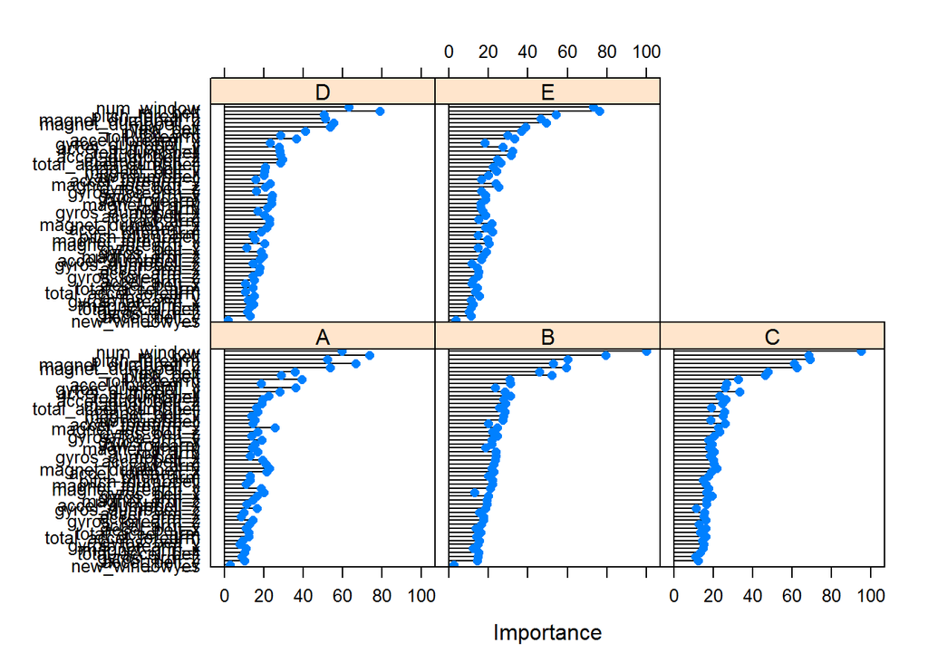

```r
library(caret)
variable.importances <- varImp(modelFit)
plot(variable.importances)
```

#### Hence we will try to train the model with less number of variables.We calculate the row sum of varaible importnaces and normalize the values.

```r
variable.importances.sums <- sort(rowSums(variable.importances$importance), decreasing =T)
variable.importances.sums <- variable.importances.sums/sum(variable.importances.sums)
```

#### If we take first 16 variables we have gathered 50 percent of total importnaces.

```r
sum(variable.importances.sums[1:16])
```

```
## [1] 0.5074567
```

```r
new.train.vars <- c("classe", names(variable.importances.sums[1:16]))
new.train.data <- pm1.data.train[, colnames(pm1.data.train) %in% new.train.vars]
new.test.data <- pm1.data.test[, colnames(pm1.data.train) %in% new.train.vars]
modelFit.reduced <- train(classe ~ ., data = new.train.data, method="rf", importance=TRUE)
```

### Predicting again the test data with the new model

```r
confusionMatrix(new.test.data$classe, predict(modelFit.reduced,new.test.data))
```

```
## Confusion Matrix and Statistics
##
##           Reference
## Prediction    A    B    C    D    E
##          A 2230    1    0    0    1
##          B    0 1517    0    1    0
##          C    0    2 1365    1    0
##          D    0    0    1 1284    1
##          E    0    4    0    5 1433
##
## Overall Statistics
##
##                Accuracy : 0.9978
##                  95% CI : (0.9965, 0.9987)
##     No Information Rate : 0.2842
##     P-Value [Acc > NIR] : < 2.2e-16
##
##                   Kappa : 0.9973
##  Mcnemar's Test P-Value : NA
##
## Statistics by Class:
##
##                      Class: A Class: B Class: C Class: D Class: E
## Sensitivity            1.0000   0.9954   0.9993   0.9946   0.9986
## Specificity            0.9996   0.9998   0.9995   0.9997   0.9986
## Pos Pred Value         0.9991   0.9993   0.9978   0.9984   0.9938
## Neg Pred Value         1.0000   0.9989   0.9998   0.9989   0.9997
## Prevalence             0.2842   0.1942   0.1741   0.1645   0.1829
## Detection Rate         0.2842   0.1933   0.1740   0.1637   0.1826
## Detection Prevalence   0.2845   0.1935   0.1744   0.1639   0.1838
## Balanced Accuracy      0.9998   0.9976   0.9994   0.9971   0.9986
```